# Measure Of Variability Assignment

Mike LeVan

2025-03-11

## Exercises

In this assignment, you will practice calculating descriptive statistics (range, variance, standard deviation, and 5-number summary), creating basic boxplots using `ggplot2`, and determining if the data has any outliers using the Interquartile Range (IQR). You will use built-in datasets from R for this assignment.

### Problem 1: Descriptive Statistics of Sepal Length in the `iris` Dataset

**Task:** Calculate the range, variance, standard deviation, and 5-number summary of the `Sepal.Length` column in the `iris` dataset.

**Steps:**

1. Load the `iris` dataset.
2. Calculate the range, variance, standard deviation, and 5-number summary of the `Sepal.Length` column.

**Code Example:**

```r
# Load iris dataset
data(iris)

# Calculate descriptive statistics
range_sepal_length <- range(iris$Sepal.Length)
variance_sepal_length <- var(iris$Sepal.Length)
sd_sepal_length <- sd(iris$Sepal.Length)
summary_sepal_length <- summary(iris$Sepal.Length)

range_sepal_length
```

```
## [1] 4.3 7.9
```

```r
variance_sepal_length
```

```
## [1] 0.6856935
```

```r
sd_sepal_length
```

```
## [1] 0.8280661
```

```r
summary_sepal_length
```

```
##    Min. 1st Qu.  Median    Mean 3rd Qu.    Max.
##   4.300   5.100   5.800   5.843   6.400   7.900
```

### Problem 2: Descriptive Statistics of Ozone Levels in the `airquality` Dataset

**Task:** Calculate the range, variance, standard deviation, and 5-number summary of the `Ozone` column in the `airquality` dataset after removing NA values.

**Steps:**

1. Load the `airquality` dataset.
2. Remove NA values from the `Ozone` column.
3. Calculate the range, variance, standard deviation, and 5-number summary of the `Ozone` column.

**Code Example:**

```r
# Load airquality dataset
data(airquality)

# Remove NA values from Ozone column
ozone_no_na <- na.omit(airquality$Ozone)

# Calculate descriptive statistics
range_ozone <- range(ozone_no_na)
variance_ozone <- var(ozone_no_na)
sd_ozone <- sd(ozone_no_na)
summary_ozone <- summary(ozone_no_na)

range_ozone
```

```
## [1]   1 168
```

```r
variance_ozone
```

```
## [1] 1088.201
```

```r
sd_ozone
```

```
## [1] 32.98788
```

```r
summary_ozone
```

```
##    Min. 1st Qu.  Median    Mean 3rd Qu.    Max.
##    1.00   18.00   31.50   42.13   63.25  168.00
```

### Problem 3: Boxplot of Annual Lynx Trappings in the `lynx` Dataset

**Task:** Create a basic boxplot of the annual number of lynx trapped in the `lynx` dataset.

**Steps:**

1. Load the `lynx` dataset.
2. Create a boxplot using `ggplot2`.

**Code Example:**

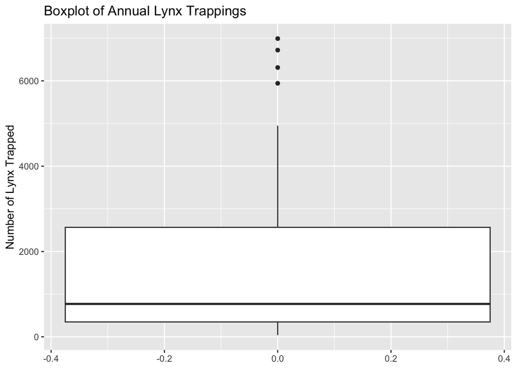

```r
# Load ggplot2 and lynx dataset
library(ggplot2)
data(lynx)

# Create boxplot
ggplot(data.frame(lynx), aes(y = lynx)) +
  geom_boxplot() +
  labs(title = "Boxplot of Annual Lynx Trappings", y = "Number of Lynx Trapped")
```

### Problem 4: Descriptive Statistics of Tooth Length in the `ToothGrowth` Dataset

**Task:** Calculate the range, variance, standard deviation, and 5-number summary of the `len` column in the `ToothGrowth` dataset.

**Steps:**

1. Load the `ToothGrowth` dataset.
2. Calculate the range, variance, standard deviation, and 5-number summary of the `len` column.

**Code Example:**

```r
# Load ToothGrowth dataset
data(ToothGrowth)

# Calculate descriptive statistics
range_len <- range(ToothGrowth$len)
variance_len <- var(ToothGrowth$len)
sd_len <- sd(ToothGrowth$len)
summary_len <- summary(ToothGrowth$len)

range_len
```

```
## [1]  4.2 33.9
```

```r
variance_len
```

```
## [1] 58.51202
```

```r
sd_len
```

```
## [1] 7.649315
```

```r
summary_len
```

```
##    Min. 1st Qu.  Median    Mean 3rd Qu.    Max.
##    4.20   13.07   19.25   18.81   25.27   33.90
```

### Problem 5: Boxplot of Age in the `infert` Dataset

**Task:** Create a basic boxplot of the `age` column in the `infert` dataset.

**Steps:**

1. Load the `infert` dataset.
2. Create a boxplot using `ggplot2`.

**Code Example:**

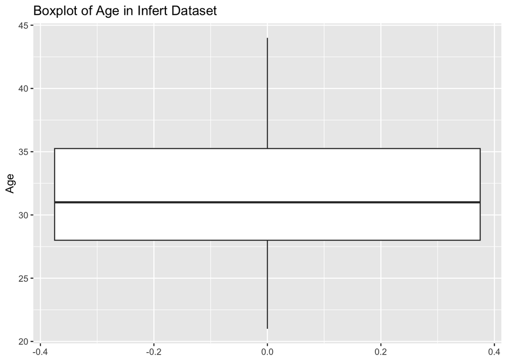

```r
# Load ggplot2 and infert dataset
library(ggplot2)
data(infert)

# Create boxplot
ggplot(infert, aes(y = age)) +
  geom_boxplot() +
  labs(title = "Boxplot of Age in Infert Dataset", y = "Age")
```

### Problem 6: Descriptive Statistics of Wind Speed in the `airquality` Dataset

**Task:** Calculate the range, variance, standard deviation, and 5-number summary of the `Wind` column in the `airquality` dataset after removing NA values.

**Steps:**

1. Load the `airquality` dataset.
2. Remove NA values from the `Wind` column.
3. Calculate the range, variance, standard deviation, and 5-number summary of the `Wind` column.

**Code Example:**

```r
# Load airquality dataset
data(airquality)

# Remove NA values from Wind column
wind_no_na <- na.omit(airquality$Wind)

# Calculate descriptive statistics
range_wind <- range(wind_no_na)
variance_wind <- var(wind_no_na)
sd_wind <- sd(wind_no_na)
summary_wind <- summary(wind_no_na)

range_wind
```

```
## [1]  1.7 20.7
```

```r
variance_wind
```

```
## [1] 12.41154
```

```r
sd_wind
```

```
## [1] 3.523001
```

```r
summary_wind
```

```
##    Min. 1st Qu.  Median    Mean 3rd Qu.    Max.
##   1.700   7.400   9.700   9.958  11.500  20.700
```

### Problem 7: Determine Outliers in Sepal Length of the `iris` Dataset

**Task:** Determine if the `Sepal.Length` column in the `iris` dataset has any outliers using the Interquartile Range (IQR).

**Steps:**

1. Load the `iris` dataset.
2. Calculate the IQR of the `Sepal.Length` column.
3. Identify any outliers in the `Sepal.Length` column.

**Code Example:**

```r
# Load iris dataset
data(iris)

# Calculate IQR
iqr_sepal_length <- IQR(iris$Sepal.Length)

# Identify outliers
q1 <- quantile(iris$Sepal.Length, 0.25)
q3 <- quantile(iris$Sepal.Length, 0.75)
lower_bound <- q1 - 1.5 * iqr_sepal_length
upper_bound <- q3 + 1.5 * iqr_sepal_length
outliers <- iris$Sepal.Length[iris$Sepal.Length < lower_bound | iris$Sepal.Length > upper_bound]

iqr_sepal_length
```

```
## [1] 1.3
```

```r
outliers
```

```
## numeric(0)
```

### Problem 8: Descriptive Statistics of Child Count in the `infert` Dataset

**Task:** Calculate the range, variance, standard deviation, and 5-number summary of the `parity` column in the `infert` dataset.

**Steps:**

1. Load the `infert` dataset.
2. Calculate the range, variance, standard deviation, and 5-number summary of the `parity` column.

**Code Example:**

```r
# Load infert dataset
data(infert)

# Calculate descriptive statistics
range_parity <- range(infert$parity)
variance_parity <- var(infert$parity)
sd_parity <- sd(infert$parity)
summary_parity <- summary(infert$parity)

range_parity
```

```
## [1] 1 6
```

```r
variance_parity
```

```
## [1] 1.566263
```

```r
sd_parity
```

```
## [1] 1.251504
```

```r
summary_parity
```

```
##    Min. 1st Qu.  Median    Mean 3rd Qu.    Max.
##   1.000   1.000   2.000   2.093   3.000   6.000
```

### Problem 9: Boxplot of Sepal Width in the `iris` Dataset

**Task:** Create a basic boxplot of the `Sepal.Width` column in the `iris` dataset.

**Steps:**

1. Load the `iris` dataset.
2. Create a boxplot using `ggplot2`.

**Code Example:**

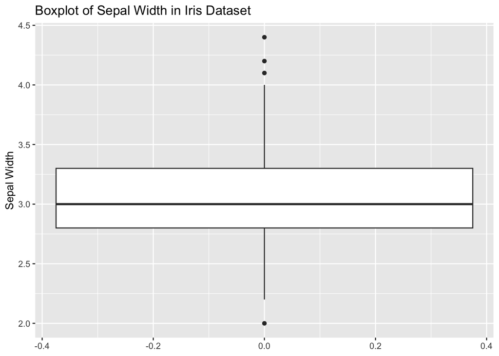

```r
# Load ggplot2 and iris dataset
library(ggplot2)
data(iris)

# Create boxplot
ggplot(iris, aes(y = Sepal.Width)) +
  geom_boxplot() +
  labs(title = "Boxplot of Sepal Width in Iris Dataset", y = "Sepal Width")
```

### Problem 10: Determine Outliers in Tooth Length of the `ToothGrowth` Dataset

**Task:** Determine if the `len` column in the `ToothGrowth` dataset has any outliers using the Interquartile Range (IQR).

**Steps:**

1. Load the `ToothGrowth` dataset.
2. Calculate the IQR of the `len` column.
3. Identify any outliers in the `len` column.

**Code Example:**

```r
# Load ToothGrowth dataset
data(ToothGrowth)

# Calculate IQR
iqr_len <- IQR(ToothGrowth$len)

# Identify outliers
q1 <- quantile(ToothGrowth$len, 0.25)
q3 <- quantile(ToothGrowth$len, 0.75)
lower_bound <- q1 - 1.5 * iqr_len
upper_bound <- q3 + 1.5 * iqr_len
outliers <- ToothGrowth$len[ToothGrowth$len < lower_bound | ToothGrowth$len > upper_bound]

iqr_len
```

```
## [1] 12.2
```

```r
outliers
```

```
## numeric(0)
```

Happy coding!